# **Predict The Bay Area’s Home Prices**

**About Data**

**Data Cleaning and Preprocessing**

- Removing unnecessary columns and converting it to int datatype
- One-Hot Encoding: Encoding categorical columns

**Exploratory Data Analysis**

- Creating a histogram of the dataset
- Creating a scatter plot
- Analyzing correlations

**Model Training and Evaluation**

- Splitting the dataset into training and testing sets
- Training Linear Regression model, Ridge model and Lasso model on the training set
- Making predictions on the testing set and evaluating the model's performance by RMSE

**Conclusion**

- Summary of the project and its findings

**Data Preprocessing**

```python
import pandas as pd
sf = pd.read_csv("https://raw.githubusercontent.com/jasondata918/dataset/main/final_data.csv")
```

```python
sf.head()
```

|  | Unnamed: 0 | address | info | z_address | bathrooms | bedrooms | finishedsqft | lastsolddate | lastsoldprice | latitude | longitude | neighborhood | totalrooms | usecode | yearbuilt | zestimate | zindexvalue | zipcode | zpid |
| --- | --- | --- | --- | --- | --- | --- | --- | --- | --- | --- | --- | --- | --- | --- | --- | --- | --- | --- | --- |
| 0 | 2 | Address: 1160 Mission Street #2007 | San FranciscoSales price: 1300000Sales date: ... | 1160 Mission St UNIT 2007 | 2.0 | 2.0 | 1043.0 | 02/17/2016 | 1300000.0 | 37.778705 | -122.412635 | South of Market | 4.0 | Condominium | 2007.0 | 1167508.0 | 975,700 | 94103.0 | 83152781.0 |
| 1 | 5 | Address: 260 King Street #475 | San FranciscoSales price: 750000Sales date: 0... | 260 King St UNIT 475 | 1.0 | 1.0 | 903.0 | 02/17/2016 | 750000.0 | 37.777641 | -122.393417 | South of Market | 3.0 | Condominium | 2004.0 | 823719.0 | 975,700 | 94107.0 | 69819817.0 |
| 2 | 7 | Address: 560 Missouri Street #B | San FranciscoSales price: 1495000Sales date: ... | 560 Missouri St # B | 4.0 | 3.0 | 1425.0 | 02/17/2016 | 1495000.0 | 37.759198 | -122.396516 | Potrero Hill | 6.0 | Condominium | 2003.0 | 1708594.0 | 1,277,600 | 94107.0 | 64972847.0 |
| 3 | 9 | Address: 350 Missouri Street | San FranciscoSales price: 2700000Sales date: ... | 350 Missouri St | 3.0 | 3.0 | 2231.0 | 02/17/2016 | 2700000.0 | 37.761886 | -122.396769 | Potrero Hill | 10.0 | SingleFamily | 1927.0 | 2411236.0 | 1,277,600 | 94107.0 | 15149489.0 |
| 4 | 11 | Address: 3658 Folsom Street | San FranciscoSales price: 1530000Sales date: ... | 3658 Folsom St | 3.0 | 3.0 | 1300.0 | 02/17/2016 | 1530000.0 | 37.740795 | -122.413453 | Bernal Heights | 4.0 | SingleFamily | 1900.0 | 1918539.0 | 1,248,000 | 94110.0 | 15161978.0 |

```python
sf.drop(['Unnamed: 0','info','z_address', 'zestimate', 'zipcode', 'zpid'], axis = 1, inplace = True)
```

```python
sf.head()
```

|  | address | bathrooms | bedrooms | finishedsqft | lastsolddate | lastsoldprice | latitude | longitude | neighborhood | totalrooms | usecode | yearbuilt | zindexvalue |
| --- | --- | --- | --- | --- | --- | --- | --- | --- | --- | --- | --- | --- | --- |
| 0 | Address: 1160 Mission Street #2007 | 2.0 | 2.0 | 1043.0 | 02/17/2016 | 1300000.0 | 37.778705 | -122.412635 | South of Market | 4.0 | Condominium | 2007.0 | 975,700 |
| 1 | Address: 260 King Street #475 | 1.0 | 1.0 | 903.0 | 02/17/2016 | 750000.0 | 37.777641 | -122.393417 | South of Market | 3.0 | Condominium | 2004.0 | 975,700 |
| 2 | Address: 560 Missouri Street #B | 4.0 | 3.0 | 1425.0 | 02/17/2016 | 1495000.0 | 37.759198 | -122.396516 | Potrero Hill | 6.0 | Condominium | 2003.0 | 1,277,600 |
| 3 | Address: 350 Missouri Street | 3.0 | 3.0 | 2231.0 | 02/17/2016 | 2700000.0 | 37.761886 | -122.396769 | Potrero Hill | 10.0 | SingleFamily | 1927.0 | 1,277,600 |
| 4 | Address: 3658 Folsom Street | 3.0 | 3.0 | 1300.0 | 02/17/2016 | 1530000.0 | 37.740795 | -122.413453 | Bernal Heights | 4.0 | SingleFamily | 1900.0 | 1,248,000 |

```python
sf.info()
```

```
<class 'pandas.core.frame.DataFrame'>
RangeIndex: 11330 entries, 0 to 11329
Data columns (total 13 columns):
 #   Column         Non-Null Count  Dtype
---  ------         --------------  -----
 0   address        11330 non-null  object
 1   bathrooms      11330 non-null  float64
 2   bedrooms       11330 non-null  float64
 3   finishedsqft   11330 non-null  float64
 4   lastsolddate   11330 non-null  object
 5   lastsoldprice  11330 non-null  float64
 6   latitude       11330 non-null  float64
 7   longitude      11330 non-null  float64
 8   neighborhood   11330 non-null  object
 9   totalrooms     11330 non-null  float64
 10  usecode        11330 non-null  object
 11  yearbuilt      11330 non-null  float64
 12  zindexvalue    11330 non-null  object
dtypes: float64(8), object(5)
memory usage: 1.1+ MB
```

```python
#Renove ","
sf['zindexvalue']= sf['zindexvalue'].str.replace(',','')
```

```python
#Object -> int
sf['zindexvalue'] = pd.to_numeric(sf['zindexvalue'])
```

```python
sf.info()
```

```
<class 'pandas.core.frame.DataFrame'>
RangeIndex: 11330 entries, 0 to 11329
Data columns (total 13 columns):
 #   Column         Non-Null Count  Dtype
---  ------         --------------  -----
 0   address        11330 non-null  object
 1   bathrooms      11330 non-null  float64
 2   bedrooms       11330 non-null  float64
 3   finishedsqft   11330 non-null  float64
 4   lastsolddate   11330 non-null  object
 5   lastsoldprice  11330 non-null  float64
 6   latitude       11330 non-null  float64
 7   longitude      11330 non-null  float64
 8   neighborhood   11330 non-null  object
 9   totalrooms     11330 non-null  float64
 10  usecode        11330 non-null  object
 11  yearbuilt      11330 non-null  float64
 12  zindexvalue    11330 non-null  int64
dtypes: float64(8), int64(1), object(4)
memory usage: 1.1+ MB
```

# 1. EDA

```python
sf['lastsolddate'].min(), sf['lastsolddate'].max()
```

```
('01/02/2013', '12/31/2015')
```

```python
sf.describe()
```

|  | bathrooms | bedrooms | finishedsqft | lastsoldprice | latitude | longitude | totalrooms | yearbuilt | zindexvalue |
| --- | --- | --- | --- | --- | --- | --- | --- | --- | --- |
| count | 11330.000000 | 11330.000000 | 11330.000000 | 1.133000e+04 | 11330.000000 | 11330.000000 | 11330.000000 | 11330.000000 | 1.133000e+04 |
| mean | 1.980229 | 2.614475 | 1585.420918 | 1.263928e+06 | 37.759711 | -122.436518 | 6.111562 | 1948.498147 | 1.320205e+06 |
| std | 1.047358 | 1.299457 | 921.978245 | 1.042079e+06 | 0.025578 | 0.030743 | 12.125819 | 37.911196 | 5.848170e+05 |
| min | 0.500000 | 0.000000 | 1.000000 | 5.350000e+02 | 37.708170 | -122.510726 | 1.000000 | 1860.000000 | 6.881000e+05 |
| 25% | 1.000000 | 2.000000 | 1019.000000 | 7.292500e+05 | 37.739286 | -122.455157 | 4.000000 | 1916.000000 | 9.829000e+05 |
| 50% | 2.000000 | 2.000000 | 1362.000000 | 9.900000e+05 | 37.760513 | -122.432510 | 5.000000 | 1940.000000 | 1.211900e+06 |
| 75% | 2.000000 | 3.000000 | 1876.000000 | 1.450000e+06 | 37.781386 | -122.413359 | 7.000000 | 1986.000000 | 1.480400e+06 |
| max | 14.000000 | 20.000000 | 27275.000000 | 2.388900e+07 | 37.806083 | -122.381201 | 1264.000000 | 2016.000000 | 5.333500e+06 |

**Histogram**

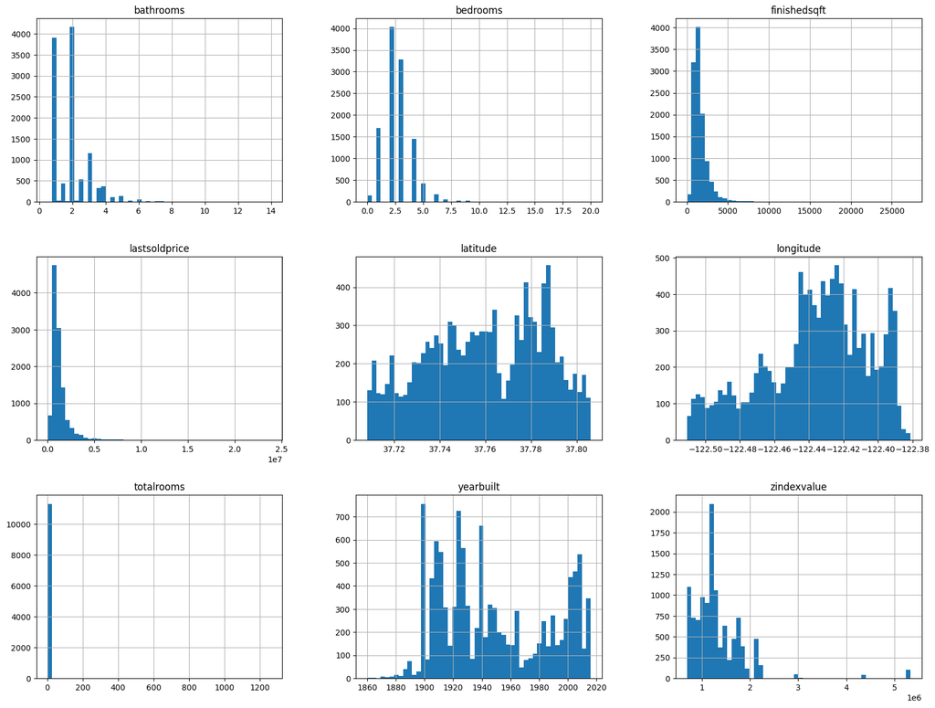

```python
import matplotlib.pyplot as plt
sf.hist(bins = 50, figsize = (20,15))
plt.show()
```

Creating a histogram of the dataset using matplotlib

- Some varialbes are little bit right skewed

**Scatter plot**

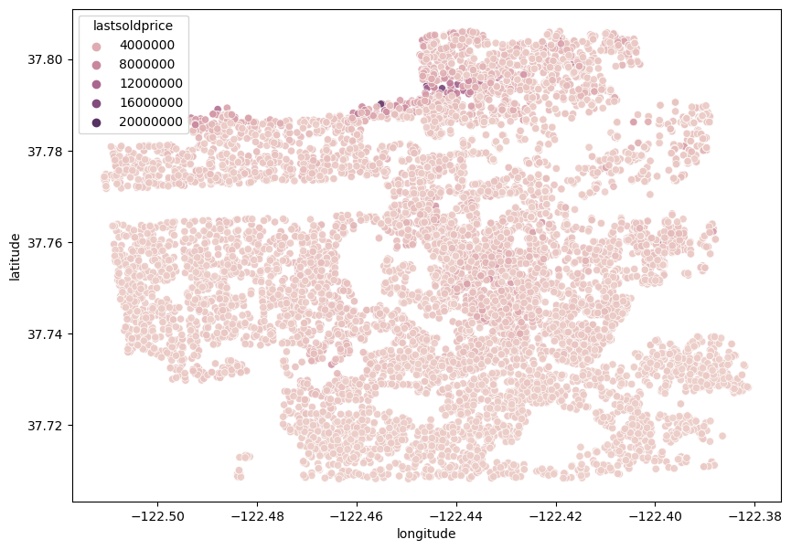

```python
import seaborn as sns
plt.figure(figsize = (10, 7))
sns.scatterplot(data =sf, x = 'longitude', y = 'latitude', alpha = 0.9, hue = 'lastsoldprice')
```

Creating a scatter plot of latitude and longitude using seaborn

- We can see that expensive houses are located in upper town in SF

**Correlation**

```python
sf.corr()
```

|  | bathrooms | bedrooms | finishedsqft | lastsoldprice | latitude | longitude | totalrooms | yearbuilt | zindexvalue |
| --- | --- | --- | --- | --- | --- | --- | --- | --- | --- |
| bathrooms | 1.000000 | 0.714270 | 0.719096 | 0.536880 | 0.041632 | -0.120276 | 0.135171 | -0.094791 | 0.249193 |
| bedrooms | 0.714270 | 1.000000 | 0.697461 | 0.395478 | -0.157859 | -0.258338 | 0.155320 | -0.312583 | 0.164981 |
| finishedsqft | 0.719096 | 0.697461 | 1.000000 | 0.647208 | 0.061655 | -0.208110 | 0.156913 | -0.283712 | 0.338131 |
| lastsoldprice | 0.536880 | 0.395478 | 0.647208 | 1.000000 | 0.283107 | -0.052595 | 0.093527 | -0.189055 | 0.460429 |
| latitude | 0.041632 | -0.157859 | 0.061655 | 0.283107 | 1.000000 | 0.117271 | -0.007126 | 0.140987 | 0.393080 |
| longitude | -0.120276 | -0.258338 | -0.208110 | -0.052595 | 0.117271 | 1.000000 | -0.054203 | 0.289189 | -0.188348 |
| totalrooms | 0.135171 | 0.155320 | 0.156913 | 0.093527 | -0.007126 | -0.054203 | 1.000000 | -0.061874 | 0.043554 |
| yearbuilt | -0.094791 | -0.312583 | -0.283712 | -0.189055 | 0.140987 | 0.289189 | -0.061874 | 1.000000 | -0.219629 |
| zindexvalue | 0.249193 | 0.164981 | 0.338131 | 0.460429 | 0.393080 | -0.188348 | 0.043554 | -0.219629 | 1.000000 |

```python
corr_matrix = sf.corr()
corr_matrix["lastsoldprice"]. sort_values(ascending = False)
```

```
lastsoldprice    1.000000
finishedsqft     0.647208
bathrooms        0.536880
zindexvalue      0.460429
bedrooms         0.395478
latitude         0.283107
totalrooms       0.093527
longitude       -0.052595
yearbuilt       -0.189055
Name: lastsoldprice, dtype: float64
```

**Plot**

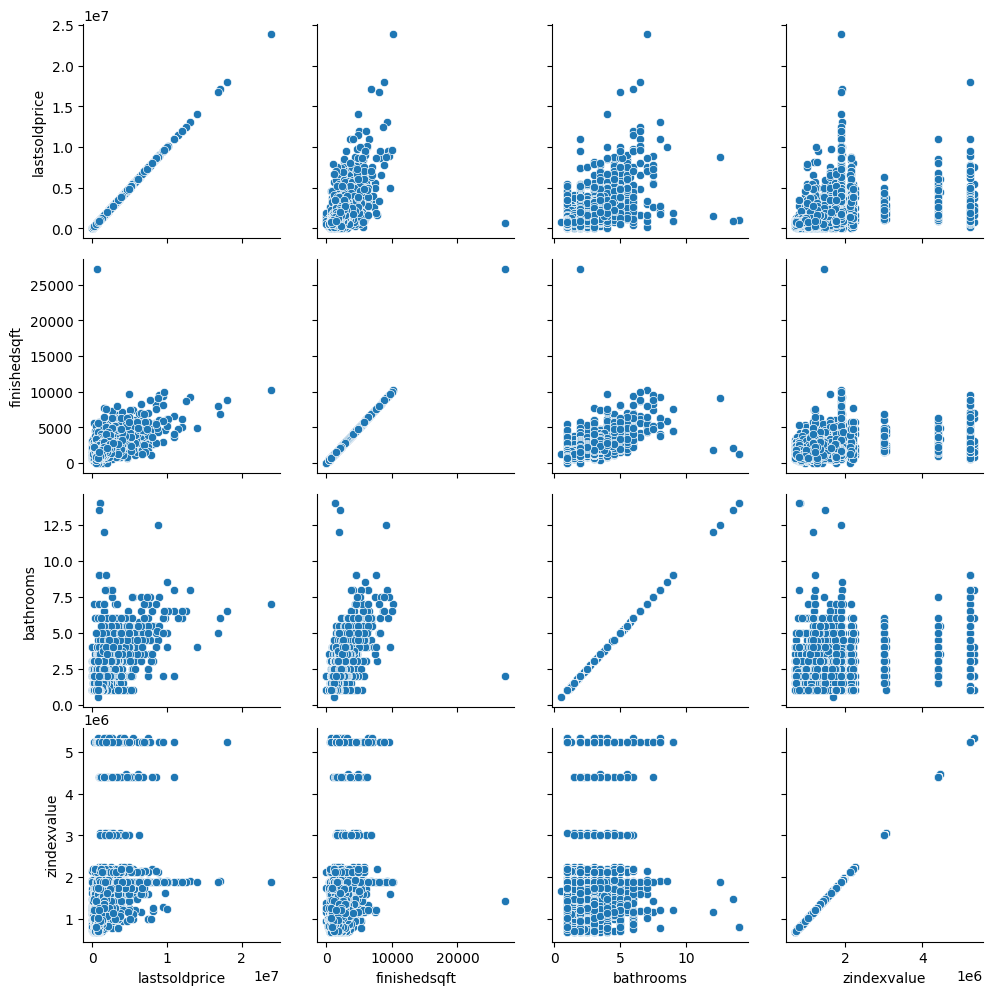

```python
g = sns.PairGrid(sf[["lastsoldprice", "finishedsqft", "bathrooms", "zindexvalue"]])
g.map(sns.scatterplot)
```

```python
sf['price_per_sqft'] = sf['lastsoldprice'] / sf['finishedsqft']
corr_matrix = sf.corr()
corr_matrix["lastsoldprice"].sort_values(ascending = False)
```

```
lastsoldprice     1.000000
finishedsqft      0.647208
bathrooms         0.536880
zindexvalue       0.460429
bedrooms          0.395478
latitude          0.283107
totalrooms        0.093527
price_per_sqft    0.005008
longitude        -0.052595
yearbuilt        -0.189055
Name: lastsoldprice, dtype: float64
```

Analyzing correlations between different columns using correlation matrices and scatterplots

- The key variable for predicting the price is the finished sqft

# 2. Neighborhood Analysis

The code groups the dataset by neighborhood and calculates the frequency and average price per square foot for each neighborhood. It then creates a new variable called "group" based on these values and merges it with the original dataset. The goal of this project could be to further explore the relationship between neighborhood and house prices and to identify which neighborhoods are the most expensive or affordable.

```python
sf['neighborhood'].nunique()
```

```
71
```

**cluster** the neighborhood into **three groups**

1. low price
2. high price low frequency
3. high price high frequency

```python
freq = sf.groupby('neighborhood').count() ['address']
mean = sf.groupby('neighborhood').mean()['price_per_sqft']
cluster = pd.concat([freq, mean], axis = 1)
cluster['neighborhood'] = cluster.index
cluster.columns = ['freq', 'price_per_sqft', 'neighborhood']
cluster.describe()
```

|  | freq | price_per_sqft |
| --- | --- | --- |
| count | 71.000000 | 71.000000 |
| mean | 159.577465 | 1664.908308 |
| std | 126.572696 | 3619.277749 |
| min | 3.000000 | 374.201197 |
| 25% | 67.500000 | 613.337664 |
| 50% | 123.000000 | 756.246284 |
| 75% | 210.500000 | 985.156646 |
| max | 540.000000 | 26914.471572 |

**Feature engineering**

- Use **one-hot encoding** to convert categorical variables such as "usecode" and "group" into numerical features that can be used in the linear regression model

```python
def get_group(x) :
  if x['price_per_sqft'] <756:
    return 'low_price'
  elif (x['price_per_sqft'] >=756) & (x['freq'] <123) :
    return 'high_price_low_freq'
  else:
    return 'high_price_high_freq'
```

```python
group = cluster.apply(get_group, axis = 1).reset_index()
```

```python
sf = sf.merge(group)
sf.rename({0:'group'}, axis = 1, inplace = True)
```

```python
sf.head()
```

|  | address | bathrooms | bedrooms | finishedsqft | lastsolddate | lastsoldprice | latitude | longitude | neighborhood | totalrooms | usecode | yearbuilt | zindexvalue | price_per_sqft | group |
| --- | --- | --- | --- | --- | --- | --- | --- | --- | --- | --- | --- | --- | --- | --- | --- |
| 0 | Address: 1160 Mission Street #2007 | 2.0 | 2.0 | 1043.0 | 02/17/2016 | 1300000.0 | 37.778705 | -122.412635 | South of Market | 4.0 | Condominium | 2007.0 | 975700 | 1246.404602 | high_price_high_freq |
| 1 | Address: 260 King Street #475 | 1.0 | 1.0 | 903.0 | 02/17/2016 | 750000.0 | 37.777641 | -122.393417 | South of Market | 3.0 | Condominium | 2004.0 | 975700 | 830.564784 | high_price_high_freq |
| 2 | Address: 300 Berry Street #813 | 1.0 | 1.0 | 761.0 | 02/17/2016 | 1000000.0 | 37.773929 | -122.396240 | South of Market | 4.0 | Condominium | 2008.0 | 975700 | 1314.060447 | high_price_high_freq |
| 3 | Address: 260 King Street #815 | 1.0 | 1.0 | 903.0 | 02/09/2016 | 800000.0 | 37.777641 | -122.393417 | South of Market | 3.0 | Condominium | 2004.0 | 975700 | 885.935770 | high_price_high_freq |
| 4 | Address: 737 Tehama Street #1 | 2.0 | 2.0 | 977.0 | 02/02/2016 | 1030000.0 | 37.775184 | -122.411567 | South of Market | 5.0 | Condominium | 2006.0 | 975700 | 1054.247697 | high_price_high_freq |

```python
sf.drop(sf.columns[[0,4,6,7,8,13]], axis = 1, inplace = True)
```

```python
sf.head()
```

|  | bathrooms | bedrooms | finishedsqft | lastsoldprice | totalrooms | usecode | yearbuilt | zindexvalue | group |
| --- | --- | --- | --- | --- | --- | --- | --- | --- | --- |
| 0 | 2.0 | 2.0 | 1043.0 | 1300000.0 | 4.0 | Condominium | 2007.0 | 975700 | high_price_high_freq |
| 1 | 1.0 | 1.0 | 903.0 | 750000.0 | 3.0 | Condominium | 2004.0 | 975700 | high_price_high_freq |
| 2 | 1.0 | 1.0 | 761.0 | 1000000.0 | 4.0 | Condominium | 2008.0 | 975700 | high_price_high_freq |
| 3 | 1.0 | 1.0 | 903.0 | 800000.0 | 3.0 | Condominium | 2004.0 | 975700 | high_price_high_freq |
| 4 | 2.0 | 2.0 | 977.0 | 1030000.0 | 5.0 | Condominium | 2006.0 | 975700 | high_price_high_freq |

# 3. Building a predictive model

The code builds a linear regression model to predict the last sold price of a property based on various features such as bathrooms, bedrooms, finished square feet, total rooms, year built, and neighborhood. The goal of building a predictive model is to accurately predict the last sold price of a property based on its features.

**Model Training and Evaluation**

- Splitting the dataset into training and testing sets
- Training a linear regression model on the training set

```python
X = sf[['bathrooms', 'bedrooms', 'finishedsqft', 'totalrooms', 'usecode', 'yearbuilt','zindexvalue','group']]
y = sf['lastsoldprice']
```

```python
X = pd.get_dummies(X, columns = ['usecode', 'group'])
```

```python
X.head()
```

|  | bathrooms | bedrooms | finishedsqft | totalrooms | yearbuilt | zindexvalue | usecode_Apartment | usecode_Condominium | usecode_Cooperative | usecode_Duplex | usecode_Miscellaneous | usecode_Mobile | usecode_MultiFamily2To4 | usecode_MultiFamily5Plus | usecode_SingleFamily | usecode_Townhouse | group_high_price_high_freq | group_high_price_low_freq | group_low_price |
| --- | --- | --- | --- | --- | --- | --- | --- | --- | --- | --- | --- | --- | --- | --- | --- | --- | --- | --- | --- |
| 0 | 2.0 | 2.0 | 1043.0 | 4.0 | 2007.0 | 975700 | 0 | 1 | 0 | 0 | 0 | 0 | 0 | 0 | 0 | 0 | 1 | 0 | 0 |
| 1 | 1.0 | 1.0 | 903.0 | 3.0 | 2004.0 | 975700 | 0 | 1 | 0 | 0 | 0 | 0 | 0 | 0 | 0 | 0 | 1 | 0 | 0 |
| 2 | 1.0 | 1.0 | 761.0 | 4.0 | 2008.0 | 975700 | 0 | 1 | 0 | 0 | 0 | 0 | 0 | 0 | 0 | 0 | 1 | 0 | 0 |
| 3 | 1.0 | 1.0 | 903.0 | 3.0 | 2004.0 | 975700 | 0 | 1 | 0 | 0 | 0 | 0 | 0 | 0 | 0 | 0 | 1 | 0 | 0 |
| 4 | 2.0 | 2.0 | 977.0 | 5.0 | 2006.0 | 975700 | 0 | 1 | 0 | 0 | 0 | 0 | 0 | 0 | 0 | 0 | 1 | 0 | 0 |

```python
from sklearn.model_selection import train_test_split

X_train, X_test, y_train, y_test = train_test_split(X,y, test_size =0.3, random_state = 100)
```

**Linear Regression**

```python
from sklearn.linear_model import LinearRegression
regressor = LinearRegression()
```

```python
regressor.fit(X_train,y_train)
```

```
LinearRegression()
```

```python
y_pred_lr = regressor.predict(X_test)
```

```python
y_pred_lr
```

```
array([ 575029.64584889, 4109327.95567206, 1139871.13787988, ...,
        676875.32121404, 2257035.90894042, 1935364.54698009])
```

```python
rmse_lr = np.sqrt(mean_squared_error(y_test, y_pred_lr))
print("Linear Regression RMSE = ", np.round(rmse_lr,2))
```

```
Linear Regression RMSE =  653708.55
```

**Ridge Model**

```python
from sklearn.linear_model import Ridge
```

```python
ridge = Ridge(alpha = 0.5)
ridge.fit(X_train,y_train)
```

```
Ridge(alpha=0.5)
```

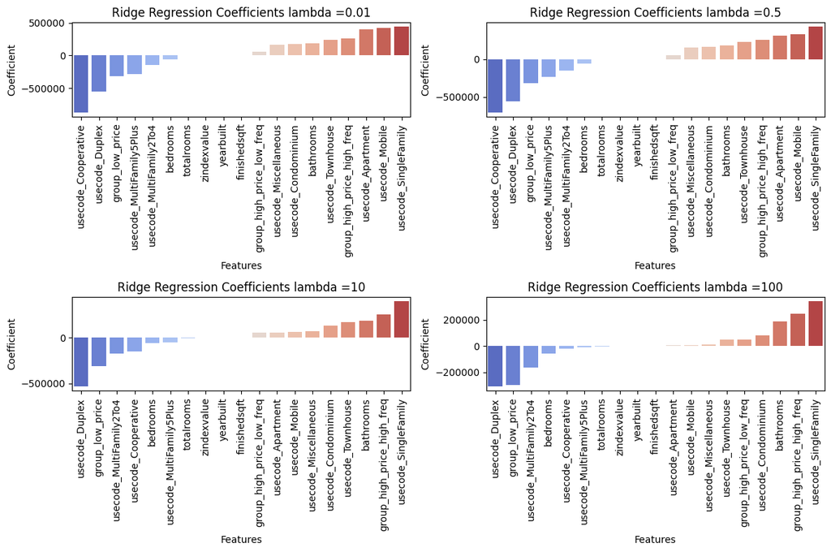

```python
fig, axes = plt.subplots(nrows=2, ncols=2, figsize=(12,8))
alphas = [0.01, 0.5, 10, 100]

for alpha, ax in zip(alphas, axes.flatten()):
    ridge = Ridge(alpha=alpha)
    ridge.fit(X_train, y_train)

    coef = pd.Series(ridge.coef_, index=X_train.columns).sort_values()
    sns.barplot(x=coef.index, y=coef.values, ax=ax, palette='coolwarm')
    ax.set_xticklabels(coef.index, rotation=90)
    ax.set_xlabel('Features')
    ax.set_ylabel('Coefficient')
    ax.set_title('Ridge Regression Coefficients lambda ={}'.format(alpha))

plt.tight_layout()
plt.show()
```

```python
y_pred_ridge = ridge.predict(X_test)
```

```python
y_pred_ridge
```

```
array([ 575276.60547249, 4108978.08916079, 1140040.45098781, ...,
        677068.82128726, 2257136.28625544, 1935259.07829105])
```

```python
rmse_ridge = np.sqrt(mean_squared_error(y_test, y_pred_ridge))
print("Ridge Model RMSE = ", np.round(rmse_ridge,2))
```

```
Ridge Model RMSE =  653617.63
```

**Lasso Model**

```python
from sklearn.linear_model import Lasso
from sklearn.linear_model import LassoCV
```

```python
lasso = LassoCV(cv=10, random_state=123, max_iter=999)
```

```python
lasso.fit(X_train,y_train)
```

```
LassoCV(cv=10, max_iter=999, random_state=123)
```

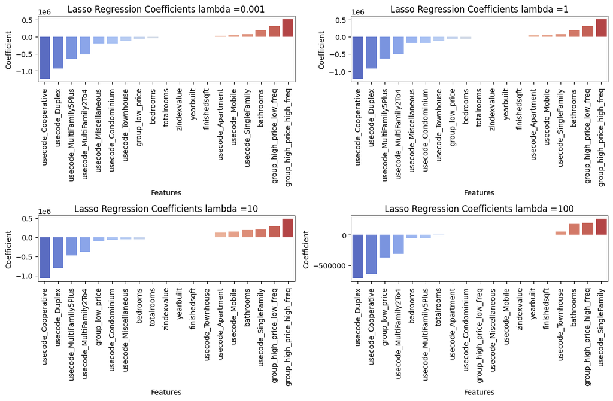

```python
fig, axes = plt.subplots(nrows=2, ncols=2, figsize=(12,8))
alphas = [0.001, 1, 10, 100]

for alpha, ax in zip(alphas, axes.flatten()):
    lasso = Lasso(alpha=alpha)
    lasso.fit(X_train, y_train)

    coef = pd.Series(lasso.coef_, index=X_train.columns).sort_values()
    sns.barplot(x=coef.index, y=coef.values, ax=ax, palette='coolwarm')
    ax.set_xticklabels(coef.index, rotation=90)
    ax.set_xlabel('Features')
    ax.set_ylabel('Coefficient')
    ax.set_title('Lasso Regression Coefficients lambda ={}'.format(alpha))

plt.tight_layout()
plt.show()
```

```python
lasso = Lasso(alpha = 10)
lasso.fit(X_train,y_train)
```

```
Lasso(alpha=10)
```

```python
y_pred_lasso = lasso.predict(X_test)
```

```python
y_pred_lasso
```

```
array([ 575119.66760801, 4109180.96169203, 1139938.42166432, ...,
        676950.28287741, 2257049.94293932, 1935300.7947459 ])
```

```python
rmse_lasso = np.sqrt(mean_squared_error(y_test, y_pred_lasso))
print("Lasso Model RMSE = ", np.round(rmse_lasso,2))
```

```
Lasso Model RMSE =  653687.43
```

# 4. Model Evaluation

The code evaluates the performance of the linear regression model using root mean squared error (RMSE). Model evaluation is an essential step in the data analysis process as it allows for the identification of potential issues with the model, such as overfitting or underfitting.

```python
import numpy as np
from sklearn.metrics import mean_squared_error
```

```python
print("Linear Regression RMSE = ", np.round(rmse_lr,2))
print("Ridge Model RMSE = ", np.round(rmse_ridge,2))
print("Lasso Model RMSE = ", np.round(rmse_lasso,2))
```

```
Linear Regression RMSE =  653708.55
Ridge Model RMSE =  653617.63
Lasso Model RMSE =  653687.43
```

# 5. Conclusion

Overall, the goal of this project is to use data analysis techniques to gain insights into the housing market in San Francisco and build a predictive model that can accurately predict the last sold price of a property.

- Based on the RMSE values provided, it seems that the Ridge model performs slightly better than both the Linear Regression and Lasso models. However, the difference in the RMSE values is not very large, so further analysis may be necessary to determine which model is truly the best fit for the data.

```python
!jupyter nbconvert --to html BayAreaHP.ipynb
```